# French vs. Dutch Rap Comparison (CM23)

Alihan

2023-02-15

# Computational_Musicology_2023-

Repository used for my “Computational Musicology” course portfolio.

## PLEASE DO NOT SHOW THIS PORTFOLIO IN CLASS

## Week 6

My corpus (https://open.spotify.com/playlist/7KtmJXjsDmw8WEdtyL28L3?si=0448a854bfd84eb5) consists of 300 tracks by the following French and Dutch rap artists and singers: Alonzo, Jul, PNL, Gims (French) and Lijpe, Boef, Sevn Alias, Josylvio (Dutch). So the corpus consists of both French and Dutch hip-hop music (raps).  
I deliberately chose this corpus because I often like listening to French and Dutch rappers myself.  
In terms of style and approach, French and Dutch rap are different, but both are characterized by their ability to engage with the issues and experiences of their respective communities, and both have made significant contributions to the development of hip-hop as a global cultural form. It is therefore worth researching rap music of both languages where we will look at the differences and similarities between the two.

The natural groups are French rappers (Alonzo, Jul, PNL, Gims) and Dutch rappers (Lijpe, Boef, Sevn Alias, Josylvio).  
French rap is more characterized by its strong tradition of chanson (which is a style of song that emphasizes vocal performance and poetic lyrics) and French rappers often incorporate African and Carribean music into their work, while Dutch rappers incorporate elements of gabber and house into their work.  
Both groups produce rap which means that they both use a very fast and energetic flow as well as techniques such as Onomatopoeaia (sue of words that imitate sounds, such as “boom” or “snap”).  
However, I am curious to see what the analyses will show. Each rapper obviously has his own way of rapping and, of course, does not always use the same technique. It is therefore important to generalise as much as possible when comparing raps in two languages. Moreover, I tried to keep the rappers as representative as possible.

Some typical ypical tracks in my corpus are Ciao La France (Alonzo), Namek (Jul) and Hoofdpijn (Lijpe)

## Week 7

Description plot 1: In general, hip hop music is known for having a strong beat and a high level of energy. This is reflected in the tempo and danceability of many hip hop tracks, which are often fast and rhythmically complex.  
Plot 1 really shows this relationship. A large proportion of tracks correspond to high energy and the “danceability” is well over 0.5 on average. Furthermore, we see interesting differences such as that the average tempo of Dutch raps is lower than French raps. The tempo distribution of French raps is greater than that of Dutch raps. This may be the reason why French raps more often give me more energy than Dutch raps.

```r
library(tidyverse)
library(spotifyr)

df <- get_playlist_audio_features("", "7KtmJXjsDmw8WEdtyL28L3?si=78d85d115b1b42c9")

conditions <- c("QUARTIERS NORD", "Les dernières volontés de Mozart (Symphony)", "Cœur blanc", "Deux frères",
                "L'EMPIRE DE MÉROÉ", "Dans la légende", "Capo Dei Capi Vol. II & III")
df$language <- ifelse(df$track.album.name %in% conditions, "French", "Dutch")

df_dutch <- df[df$language == "Dutch", ]
df_french <- df[df$language == "French", ]

cm23 <-
  bind_rows(
    df_french |> mutate(category = "French"),
    df_dutch |> mutate(category = "Dutch")
  )
```

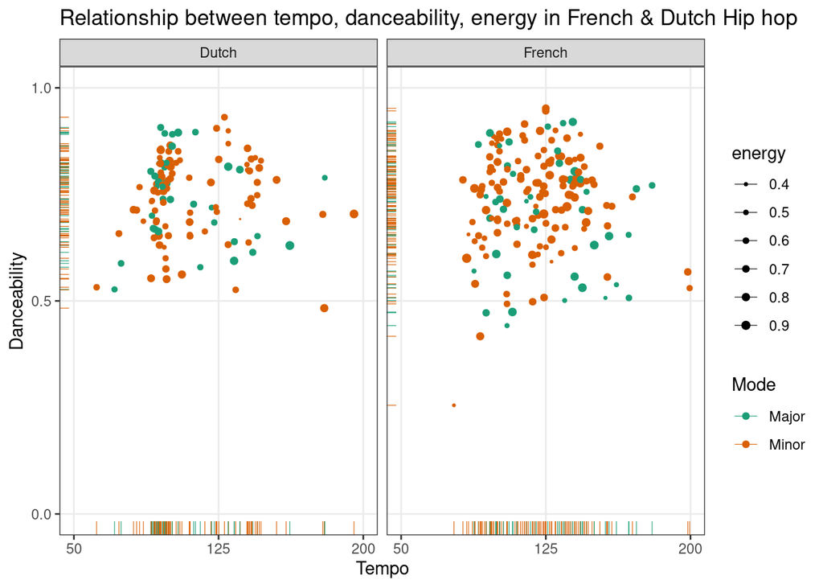

```r
cm23 |>
  mutate(
    mode = ifelse(mode == 0, "Minor", "Major")
  ) |>
  ggplot(
    aes(
      x = tempo,
      y = danceability,
      size = energy,
      colour = mode
    )
  ) +
  geom_point() +
  geom_rug(linewidth = 0.2) +
  facet_wrap(~ category) +
  scale_x_continuous(
    limits = c(50, 200),
    breaks = c(50, 125, 200),
    minor_breaks = NULL
  ) +
  scale_y_continuous(
    limits = c(0, 1),
    breaks = c(0, 0.50, 1),
    minor_breaks = NULL
  ) +
  scale_colour_brewer(
    type = "qual",
    palette = "Dark2"
  ) +
  scale_size_continuous(
    trans = "exp",
    #guide = "none",
    range = c(0, 2)
  ) +
  theme_bw() +
  labs(
    x = "Tempo",
    y = "Danceability",
    colour = "Mode"
  ) + ggtitle("Relationship between tempo, danceability, energy in French & Dutch Hip hop")
```

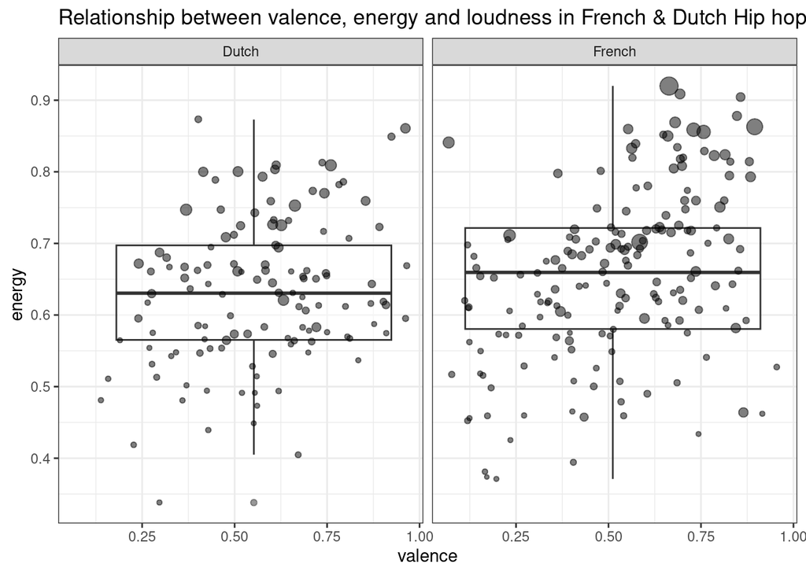

```r
ggplot(cm23, mapping = aes(x = valence, y = energy, size=loudness)) +
  geom_boxplot(alpha = 0.5) +
  geom_jitter(alpha = 0.5, color = "black") +
  facet_wrap(~ category) +
  scale_size_continuous(
    trans = "exp",
    guide = "none",
    range = c(1, 5)) +
  ggtitle("Relationship between valence, energy and loudness in French & Dutch Hip hop") +
  theme_bw()
```